# PROSPER LOAN DATA

### DISTRIBUTION FOR THE STATED MONTHLY LOAN INCOME IN EACH OCCUPATION CATEGORIS

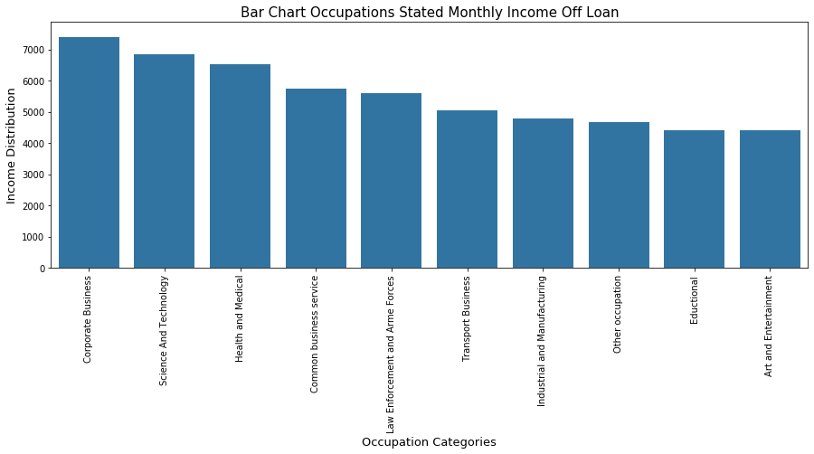

```python
columnsName_x = 'occupation_categories'
columnsName_y = 'statedmonthlyincome'
graphetile = 'Bar Chart Occupations Stated Monthly Income Off Loan'
bar_dtributioin(columnsName_x, columnsName_y, graphetile)
```

#### OBSERVATION

- This bar chart displace the occupation categoreis with the most income stated for loan in which the `corperate business` has the maximum plotted average stated incomme ranging at 7000 upword
- `art and entertinment` occupation categories with `educational` occupation categories has a minial plotted average stated incomme ranging at 4500 downword

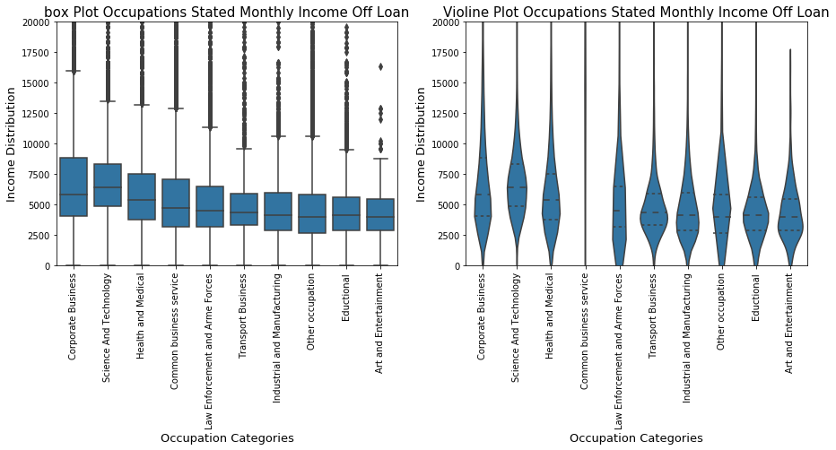

```python
#  box_Violine(columnsName_x, columnsName_y, title_one, title_two, boundaries=(0, 20000))
columnsName_x = 'occupation_categories'
columnsName_y = 'statedmonthlyincome'
title_one = 'box Plot Occupations Stated Monthly Income Off Loan'
xlabel = 'Occupation Categories'
title_two = 'Violine Plot Occupations Stated Monthly Income Off Loan'

box_Violine(columnsName_x, columnsName_y, title_one, title_two, xlabel)
```

#### OBSERVATION

- From the ploted boxplot Graph we can conclude on the stated monthly income maximum values from all occupation categories is from 8000 upwords
- From the Viloline plot we can conclude the average stated monthly income for each occupation categories is the range of 2500 and above
- From this Observation a large number of outliers was observed in each occupation categories which then required a limitation on the y axis of `0` lower boundry to `20000` upper boundry

### DISTRIBUTION OF MONTHLY LOAN PAYMENT IN EACH OCCUPATION CATEGORIS

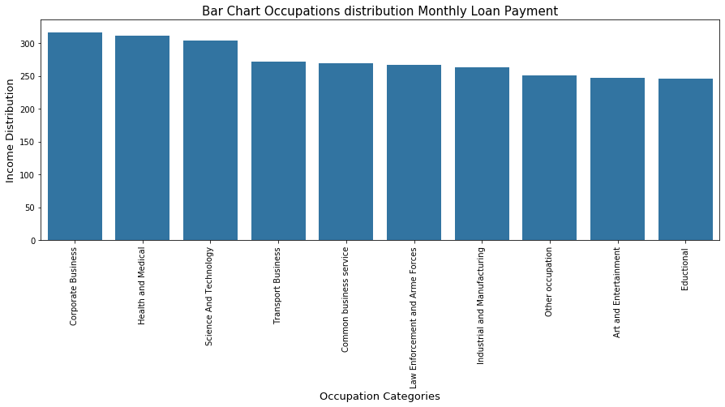

```python
columnsName_x = 'occupation_categories'
columnsName_y = 'monthlyloanpayment'
graphetile = 'Bar Chart Occupations distribution Monthly Loan Payment'
bar_dtributioin(columnsName_x, columnsName_y, graphetile)
```

#### OBSERVATION

- From the Observation of the monthly loan payment for each Occupation categories commpered to their stated monthly income the `Corporate Business` still has the largest average on monthly loan payment
- From the Observation the `Educational, Other Occupation, and Art and Entertainment` Occupation categories all has the minimum rage from 250 to 240

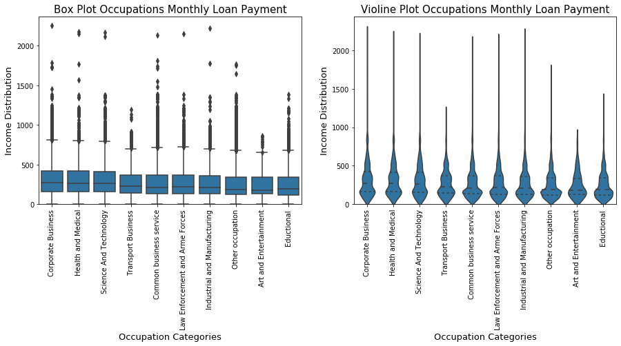

```python
columnsName_x = 'occupation_categories'
columnsName_y = 'monthlyloanpayment'
title_one = 'Box Plot Occupations Monthly Loan Payment'
title_two = 'Violine Plot Occupations Monthly Loan Payment'
xlabel = 'Occupation Categories'
boundaries = 0
box_Violine(columnsName_x, columnsName_y, title_one, title_two, xlabel, boundaries=boundaries)
```

#### OBSERVATION

- From the ploted boxplot Graph we can conclude on the monthly loan payment maximum values from all occupation categories is from 500 upwords
- From the Viloline plot we can conclude the average monthly loan payment for each occupation categories is the range of 500 downwords in all categoies
- From this Observation a large number of outliers was observed in each occupation categories which are `1.5` away from the **IQR**

### DISTRIBUTION OF MONTHLY LOAN PAYMENT PER YEAR

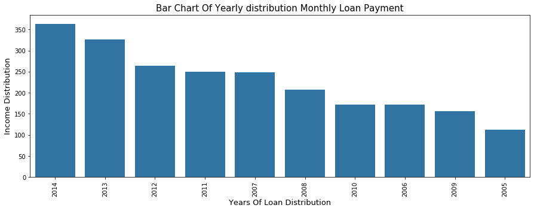

```python
columnsName_x = 'year_loan_created'
columnsName_y = 'monthlyloanpayment'
graphetile = 'Bar Chart Of Yearly distribution Monthly Loan Payment'
bar_dtributioin(columnsName_x, columnsName_y, graphetile)
plt.xlabel('Years Of Loan Distribution', fontsize=13);
```

#### OBSERVATION

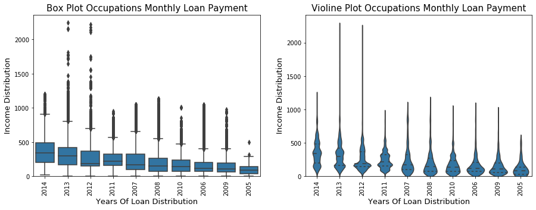

```python
columnsName_x = 'year_loan_created'
columnsName_y = 'monthlyloanpayment'
title_one = 'Box Plot Occupations Monthly Loan Payment'
title_two = 'Violine Plot Occupations Monthly Loan Payment'
xlabel = 'Years Of Loan Distribution'
boundaries = 0
box_Violine(columnsName_x, columnsName_y, title_one, title_two, xlabel, boundaries=boundaries)
```

#### OBSERVATION

- From this observation from the violine plot the average of all years monthly loan payment is below 500
- From this observation from the box plot the maximum values of monthli loan payment are less than 1000
- From the Observation from both the violine and box plot we can clearly see that the years `2013` and `2012` has the most outliers ranging even more than 2000 upwards compered to other years which their outliers fall below 1500

### CORRELATION BETWEEN STATED MONTHLY INCOME AND MONTHLY LOAN PAYMENT

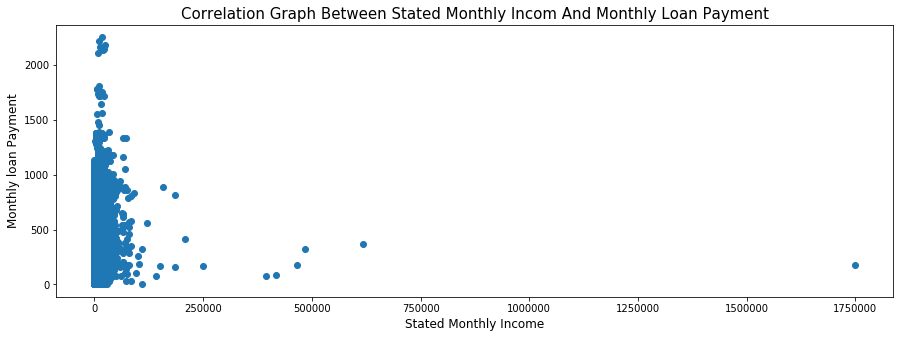

```python
plt.figure(figsize=[15, 5])
plt.scatter(data=prosper_loan_copy, x='statedmonthlyincome', y='monthlyloanpayment')
plt.title('Correlation Graph Between Stated Monthly Incom And Monthly Loan Payment', fontsize=15)
plt.xlabel('Stated Monthly Income', fontsize=12)
plt.ylabel('Monthly loan Payment', fontsize=12);
```

#### OBSERVATION

- As it was observes in the histogram of both stated monthly income and monthly loan payment which both gave a discreet histogram
- From this scatter plot the check for correlation between the stated monthly income and monthly loan payment is not linearly displaced as seen which will then require a log transfrom on both axis

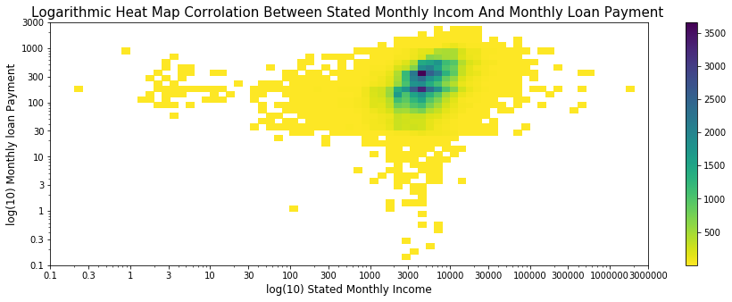

```python
plt.figure(figsize=[15, 5])
bins_x = 10**np.arange(-1, 6.24+0.1, 0.1)
bins_y = 10**np.arange(-1, 3.35+0.1, 0.1)

plt.hist2d(data=prosper_loan_copy, x='statedmonthlyincome', y='monthlyloanpayment', cmin=0.5, cmap='viridis_r',
           bins=[bins_x, bins_y]);
plt.xscale('log')
plt.yscale('log')
plt.colorbar()
xticks = [0.1, 0.3, 1, 3, 10, 30, 100, 300, 1000, 3000, 10000, 30000, 100000, 300000, 1000000, 3000000]
yticks = [0.1, 0.3, 1, 3, 10, 30, 100, 300, 1000, 3000]
xticks_str = ['{}'.format(x) for x in xticks]
yticks_str = ['{}'.format(x) for x in xticks]
plt.xticks(xticks, xticks_str)
plt.yticks(yticks, yticks_str)
plt.title('Logarithmic Heat Map Corrolation Between Stated Monthly Incom And Monthly Loan Payment ', fontsize=15)
plt.xlabel('log(10) Stated Monthly Income', fontsize=12)
plt.ylabel('log(10) Monthly loan Payment', fontsize=12);
```

#### OBSERVATION

- From the observation of the Logarithm heatmap corrolation between stated monthly Income and Mothly Loan payment we can observe a linearly correlation between both axis
- From the observation the is more of occuring correlation between `1000 t0 30000` on the stated monthly Income axis and `30 to 1000` on the Mothly Loan payment axis

### EACH YEARS OF LOAN AND THE OCCUPATION CATEGORIES WITH THE MUST COMMON REQUEST

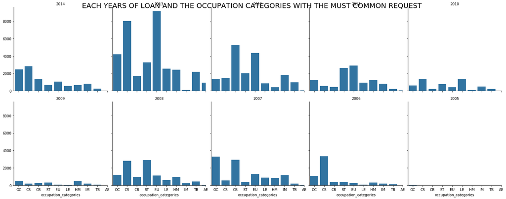

```python
col_order = prosper_loan_status['year_loan_created'].value_counts().index.sort_values(ascending=False)
g = sb.FacetGrid(data=prosper_loan_status, col='year_loan_created', col_wrap=5, height=4, col_order=col_order)
g.map(sb.countplot, 'occupation_categories')
g.set_titles('{col_name}')
xtickslabel = ['OC', 'CS', 'CB', 'ST', 'EU', 'LE', 'HM', 'IM', 'TB', 'AE']

g.set(xticks=[0, 1, 2, 3, 4, 5, 6, 7, 8, 9], xticklabels=xtickslabel)
g.fig.suptitle('EACH YEARS OF LOAN AND THE OCCUPATION CATEGORIES WITH THE MUST COMMON REQUEST', fontsize=20);
```

#### OBSERVATION

- `HM` MEANS Health and Medical
- `AE` MEANS Art and Entertainment
- `CS` MEANS Common business service
- `CB` MEANS Corporate Business
- `TB` MEANS Transport Business
- `IM` MEANS Industrial and Manufacturing
- `LE` MEANS Law Enforcement and Arme Forces
- `ST` MEANS Science And Technology
- `EU` MEANS Eductional
- `OC` MEANS Other occupation

#### OBSERVATION

- **2014**
  - `CS` Common business service had the maximum occurence of prosper loan
  - `AE` Art and Entertainment had the minimum occurence of prosper loan
- **2013**
  - `EU` Eductional had the maximum occurence of prosper loan
  - `IM` Industrial and Manufacturing had the minimum occurence of prosper loan
- **2012**
  - `CB` Corporate Business had the maximum occurence of prosper loan
  - `AE` Art and Entertainment had the minimum occurence of prosper loan
- **2011**
  - `EU` Eductional had the maximum occurence of prosper loan
  - `AE` Art and Entertainment had the minimum occurence of prosper loan
- **2010**
  - `LE` Law Enforcement and Arme Forces had the maximum occurence of prosper loan slightly higher than `CS` Common business service
  - `AE` Art and Entertainment had the minimum occurence of prosper loan
- **2009**
  - `HM` Health and Medical with `OC` Other occupation had the maximum occurence of prosper loan
  - `AE` Art and Entertainment had the minimum occurence of prosper loan
- **2008**
  - `ST` Science And Technology had the maximum occurence of prosper loan slightly higher than `CS` Common business service
  - `AE` Art and Entertainment had the minimum occurence of prosper loan
- **2007**
  - `OC` Other occupation had the maximum occurence of prosper loan
  - `AE` Art and Entertainment had the minimum occurence of prosper loan
- **2006**
  - `CS` Common business service had the maximum occurence of prosper loan
  - `AE` Art and Entertainment had the minimum occurence of prosper loan
- **2005**
  - no request could be observed because the occurence of any occupational categorise was very low

## Multivariate Exploration

### STATED MONTHLY LOAN PAYMENT VARIANCE IN EACH OCCUPATION CATEGORIES FOR EACH YEAR

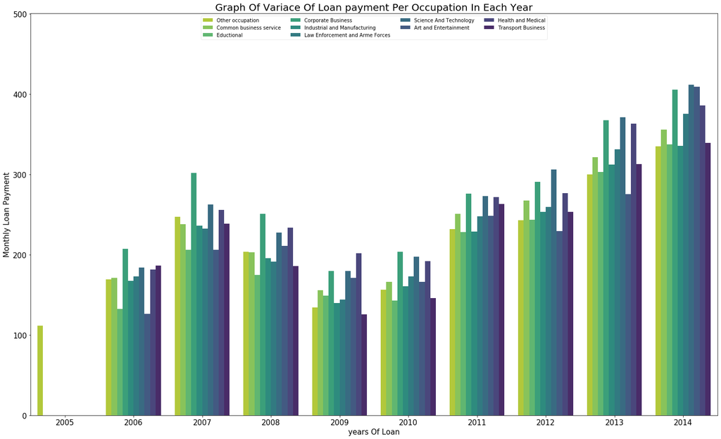

```python
plt.figure(figsize=[25, 15])
sb.barplot(data=prosper_loan_status, x='year_loan_created', y='monthlyloanpayment', hue='occupation_categories',
          palette='viridis_r', errwidth=0)
plt.title('Graph Of Variace Of Loan payment Per Occupation In Each Year', fontsize=20)
plt.xlabel('years Of Loan', fontsize=15)
plt.ylabel('Monthly Loan Payment', fontsize=15)
plt.yticks(fontsize=15)
plt.xticks(fontsize=15)
plt.legend(framealpha=0.4, ncol=4);
```

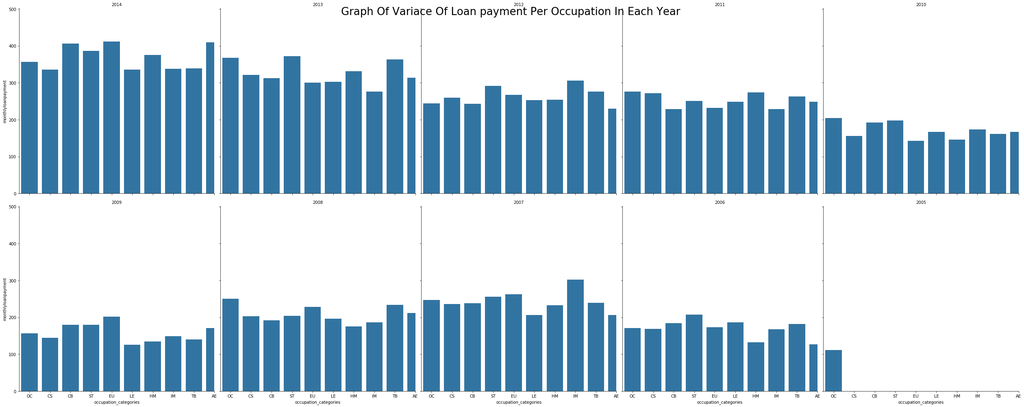

```python
g = sb.FacetGrid(data=prosper_loan_status, col='year_loan_created', col_wrap=5, height=7, col_order=col_order)
g.map(sb.barplot, 'occupation_categories', 'monthlyloanpayment', errwidth=0)
g.set_titles('{col_name}')
xtickslabel = ['OC', 'CS', 'CB', 'ST', 'EU', 'LE', 'HM', 'IM', 'TB', 'AE']
g.set(xticks=[0, 1, 2, 3, 4, 5, 6, 7, 8, 9], xticklabels=xtickslabel)
g.fig.suptitle('Graph Of Variace Of Loan payment Per Occupation In Each Year', fontsize=26);
```

#### OBSERVATION

- `HM` MEANS Health and Medical
- `AE` MEANS Art and Entertainment
- `CS` MEANS Common business service
- `CB` MEANS Corporate Business
- `TB` MEANS Transport Business
- `IM` MEANS Industrial and Manufacturing
- `LE` MEANS Law Enforcement and Arme Forces
- `ST` MEANS Science And Technology
- `EU` MEANS Eductional
- `OC` MEANS Other occupation

#### OBSERVATION

- **2014**
  - `CB` Corporate Business, `EU` Eductionals and `AE` Art and Entertainment both have the maximum average montly loan payment ranging from 400 upword
  - `CS` Common business service, `LE` Law Enforcement and Arme Forces, `IM` Industrial and Manufacturing and `TB` Transport Business all have a minimum average montly loan payment ranging from 350 downword
- **2013**
  - `OC` Other occupation, `ST` Science And Technology and `TB` Transport Business both have the maximum average montly loan payment ranging from 300 upword
  - `IM` Industrial and Manufacturing have the minimum average montly loan payment ranging from 300 downwords
- **2012**
  - `IM` Industrial and Manufacturing have the maximum average of montly loan payment ranging from 400 downwords and 300 upwords which is slightly higher than `ST` Science And Technology montly loan payment average
  - `AE` Art and Entertainment have the minimum average of montly loan payment ranging from 300 downwords and 200 upwards
- **2011**
  - `OC` Other occupation had the maximum average of montly loan payment ranging from 300 downword and 250 upword slightly higher than `CS` Common business service and `HM` Health and Medical
  - `CB` Corporate Business had the minimum average of montly loan payment ranging 200 upword and 300 downword slightly lower than `EU` Eductionals and `IM` Industrial and Manufacturing
- **2010**
  - `OC` Other occupation have the maximum average of montly loan payment ranging from 300 downwords and 200 upwords slightly higher than `ST` Science And Technology
  - `EU` Eductionals had the minimum average of montly loan payment ranging from 200 downwords and 100 upwards slightly lower than `IM` Industrial and Manufacturing
- **2009**
  - `EU` Eductionals have the maximum average montly loan payment ranging from 200 upword
  - `LE` Law Enforcement and Arme Forces have the minimum average montly loan payment ranging from 150 downwords
- **2008**
  - `OC` Other occupation have the maximum average montly loan payment ranging between 200 upword and 300 downword slightly higher than `EU` Eductional and `TB` Transport Business
  - `HM` Health and Medical have the minimum average of montly loan payment ranging from 200 downwords
- **2007**
  - `IM` Industrial and Manufacturing have the maximum average of montly loan payment ranging from 300 upword
  - `AE` Art and Entertainment and `LE` Law Enforcement and Arme Forces had the minimum average of montly loan payment ranging from 200 upword and 300 downword
- **2006**
  - `ST` Science And Technology have the maximum average of montly loan payment ranging 200 upword and 300 downword
  - `AE` Art and Entertainment have the minimum average of montly loan payment ranging from 200 downwords and 100 upwards
- **2005**
  - `OC` Other occupation is the only occpationnal categore which applied for that proper loan and had an average loan of monthly loan payment of 100 upword and 200 downwords

### OCCUPATION CATEGORIES IN EACH YEAR AND THEIR VARIANCE TO STATED MONTHLY INCOME

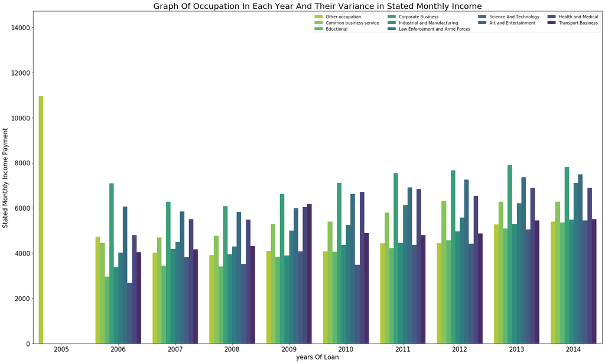

```python
plt.figure(figsize=[25, 15])
sb.barplot(data=prosper_loan_status, x='year_loan_created', y='statedmonthlyincome', hue='occupation_categories',
          palette='viridis_r', errwidth=0)
plt.title('Graph Of Occupation In Each Year And Their Variance in Stated Monthly Income', fontsize=20)
plt.xlabel('years Of Loan', fontsize=15)
plt.ylabel('Stated Monthly Income Payment', fontsize=15)
plt.yticks(fontsize=15)
plt.xticks(fontsize=15)
plt.legend(framealpha=0.4, ncol=4);
```

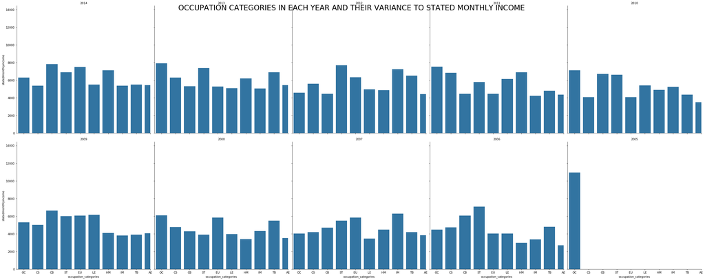

```python
g = sb.FacetGrid(data=prosper_loan_status, col='year_loan_created', col_wrap=5, height=7, col_order=col_order)
g.map(sb.barplot, 'occupation_categories', 'statedmonthlyincome', errwidth=0)
g.set_titles('{col_name}')
xtickslabel = ['OC', 'CS', 'CB', 'ST', 'EU', 'LE', 'HM', 'IM', 'TB', 'AE']
g.set(xticks=[0, 1, 2, 3, 4, 5, 6, 7, 8, 9], xticklabels=xtickslabel)
g.fig.suptitle('OCCUPATION CATEGORIES IN EACH YEAR AND THEIR VARIANCE TO STATED MONTHLY INCOME', fontsize=26);
```

#### OBSERVATION

- `HM` MEANS Health and Medical
- `AE` MEANS Art and Entertainment
- `CS` MEANS Common business service
- `CB` MEANS Corporate Business
- `TB` MEANS Transport Business
- `IM` MEANS Industrial and Manufacturing
- `LE` MEANS Law Enforcement and Arme Forces
- `ST` MEANS Science And Technology
- `EU` MEANS Eductional
- `OC` MEANS Other occupation